y4wn13.github.io/

# **The Impact of Female Representation on the Profitability of Movies**

# **Intro to Data Science Milestone 3**

*By Andrew Yawn*

### **Project Website**

[GitHub Repository](https://github.com/y4wn13/y4wn13.github.io/)

[Github Website](https://y4wn13.github.io/)

## **Project Goals and Approach: Does greater female representation show up in box office figures?**

**Focus:** The goal of this project is to examine and analyze whether female representation in movies has any noteworthy associations with box office returns.

**Why this matters:** Female representation in film has endured a winding journey that often aligns with the views shaping society at a given moment. From 1930 to 1968, the Hays Code imposed strict moral guidelines on films that many believe limited the number of independent female characters a movie could sustain. Female representation in movies has steadily increased since, and in 2014, FiveThirtyEight published a piece called ["The Dollar-And-Cents Case Against Hollywood’s Exclusion of Women"](https://fivethirtyeight.com/features/the-dollar-and-cents-case-against-hollywoods-exclusion-of-women/). This piece found that movies with more female representation earned more return on investment than those with less. This piece only examined movies up to 2013, however, and the next decade of filmmaking was marked by the #MeToo movement and seemingly more deliberate investment in movies with greater female representation. My goal is to broaden and update the analysis to see how the profitability of movies featuring female characters has changed over time and in our current moment.

I'd also like to see if I can determine whether female representation has any statistical significance when attempting to predict a film's ROI.

**A key metric:** In 1985, a cartoonist named Alison Bechdel drew a comic that unwittingly set the standard for measuring female representation in movies for the next four decades. The comic showed two women opting not to see a movie because it did not pass three criteria:

- There must be at least two women
- A conversation between two women
- A conversation between two women about anything but a man

The Bechdel Test was born, and despite its flaws, it remains the only popular standard by which female representation in movies is judged. I will be using the Bechdel Test as a key feature in this data project to categorize the level of female representation in a movie.

**Data:** I will begin this project using two datasets:

- [9000+ Movies : IMDb and Bechdel](https://www.kaggle.com/datasets/nliabzd/movies-imdb-and-bechdel-information)
- [TMDB + IMDB Merged Movies Dataset](https://www.kaggle.com/datasets/ggtejas/tmdb-imdb-merged-movies-dataset)

The first contains data for more than 9,000 films including, crucially, associated Bechdel Test scores (scale: 0-3). The data was scraped from BechdelTest.com, a website that crowdsources Bechdel scores from hundreds to thousands of users per movie.

The second contains data for more than 350,000 films pertaining to budget, revenue, genre, and other, mostly categorical labels such as language, production company and cast. It is also rife with duplicate movie IDs and movie ratings. I am planning to merge the data sets on movie title and IMDB identification numbers.

Due to file size, I uploaded the data to my Google Drive for use here.

# **Extraction, Transformation, Loading**

First, I must load and tidy the datasets.

Below, I am importing libraries that will allow me to analyze and later visualize this data.

**Importing libraries:**

**Loading the data:**

The Kaggle datasets used for this get updated occasionally. For that reason we will use the specific datasets I downloaded for this project. We will load the Bechdel.csv from Github and the TMDB.csv will be pulled from a shared Google Drive link (at 280MB, it is too large to upload to Github, even when zipped).

|  | title | year | imdbid | id | bechdelRating | imdbAverageRating | numVotes | runtimeMinutes | genre1 | genre2 | genre3 |
| --- | --- | --- | --- | --- | --- | --- | --- | --- | --- | --- | --- |
| 0 | Miss Jerry | 1894 | 9.0 | 9779 | 0 | 5.4 | 212.0 | 45 | Romance | NaN | NaN |
| 1 | Story of the Kelly Gang, The | 1906 | 574.0 | 1349 | 1 | 6.0 | 903.0 | 70 | Action | Adventure | Biography |
| 2 | Cleopatra | 1912 | 2101.0 | 2003 | 2 | 5.1 | 622.0 | 100 | Drama | History | NaN |
| 3 | A Florida Enchantment | 1914 | 3973.0 | 4457 | 2 | 5.8 | 300.0 | 63 | Comedy | NaN | NaN |
| 4 | Birth of a Nation, The | 1915 | 4972.0 | 1258 | 2 | 6.1 | 26403.0 | 195 | Drama | History | War |

```
Downloading...
From (original): https://drive.google.com/uc?id=12YMcKQRX0-9c_M_TziH3TPCNuZJecH5Q
From (redirected): https://drive.google.com/uc?id=12YMcKQRX0-9c_M_TziH3TPCNuZJecH5Q&confirm=t&uuid=ff82eb31-a74f-4200-8acc-c76652dcfaff
To: /content/TMDB.zip
```

|  | id | title | vote_average | vote_count | status | release_date | revenue | runtime | adult | backdrop_path | budget | homepage | tconst | original_language | original_title | overview | popularity | poster_path | tagline | genres | production_companies | production_countries | spoken_languages | keywords | directors | writers | averageRating | numVotes | cast |
| --- | --- | --- | --- | --- | --- | --- | --- | --- | --- | --- | --- | --- | --- | --- | --- | --- | --- | --- | --- | --- | --- | --- | --- | --- | --- | --- | --- | --- | --- |
| 0 | 27205 | Inception | 8.364 | 34495 | Released | 2010-07-15 | 825532764 | 148 | False | /8ZTVqvKDQ8emSGUEMjsS4yHAwrp.jpg | 160000000 | https://www.warnerbros.com/movies/inception | tt1375666 | en | Inception | Cobb, a skilled thief who commits corporate espionage by infiltrating the subconscious of his targets is offered a chance to regain his old life as payment for a task considered to be impossible: "inc… | 83.952 | /oYuLEt3zVCKq57qu2F8dT7NIa6f.jpg | Your mind is the scene of the crime. | Action, Science Fiction, Adventure | Legendary Pictures, Syncopy, Warner Bros. Pictures | United Kingdom, United States of America | English, French, Japanese, Swahili | rescue, mission, dream, airplane, paris, france, virtual reality, kidnapping, philosophy, spy, allegory, manipulation, car crash, heist, memory, architecture, los angeles, california, dream world, sub… | Christopher Nolan | Christopher Nolan | 8.8 | 2786952 | Leonardo DiCaprio, Joseph Gordon-Levitt, Ken Watanabe, Tom Hardy, Elliot Page, Dileep Rao, Cillian Murphy, Tom Berenger, Marion Cotillard, Pete Postlethwaite |
| 1 | 157336 | Interstellar | 8.417 | 32571 | Released | 2014-11-05 | 701729206 | 169 | False | /pbrkL804c8yAv3zBZR4QPEafpAR.jpg | 165000000 | http://www.interstellarmovie.net/ | tt0816692 | en | Interstellar | The adventures of a group of explorers who make use of a newly discovered wormhole to surpass the limitations on human space travel and conquer the vast distances involved in an interstellar voyage. | 140.241 | /gEU2QniE6E77NI6lCU6MxlNBvIx.jpg | Mankind was born on Earth. It was never meant to die here. | Adventure, Drama, Science Fiction | Legendary Pictures, Syncopy, Lynda Obst Productions | United Kingdom, United States of America | English | rescue, future, spacecraft, race against time, artificial intelligence (a.i.), nasa, time warp, dystopia, expedition, space travel, wormhole, famine, black hole, quantum mechanics, family relationship… | Christopher Nolan | Jonathan Nolan, Christopher Nolan | 8.7 | 2479726 | Matthew McConaughey, Anne Hathaway, Michael Caine, Jessica Chastain, Casey Affleck, Wes Bentley, Topher Grace, Mackenzie Foy, Ellen Burstyn, John Lithgow |
| 2 | 155 | The Dark Knight | 8.512 | 30619 | Released | 2008-07-16 | 1004558444 | 152 | False | /nMKdUUepR0i5zn0y1T4CsSB5chy.jpg | 185000000 | https://www.warnerbros.com/movies/dark-knight/ | tt0468569 | en | The Dark Knight | Batman raises the stakes in his war on crime. With the help of Lt. Jim Gordon and District Attorney Harvey Dent, Batman sets out to dismantle the remaining criminal organizations that plague the stree… | 130.643 | /qJ2tW6WMUDux911r6m7haRef0WH.jpg | Welcome to a world without rules. | Drama, Action, Crime, Thriller | DC Comics, Legendary Pictures, Syncopy, Isobel Griffiths, Warner Bros. Pictures | United Kingdom, United States of America | English, Mandarin | joker, sadism, chaos, secret identity, crime fighter, superhero, anti hero, scarecrow, based on comic, vigilante, organized crime, tragic hero, anti villain, criminal mastermind, district attorney, su… | Christopher Nolan | Jonathan Nolan, Christopher Nolan, David S. Goyer, Bob Kane | 9.1 | 3134372 | Christian Bale, Heath Ledger, Aaron Eckhart, Michael Caine, Maggie Gyllenhaal, Gary Oldman, Morgan Freeman, Monique Gabriela Curnen, Ron Dean, Cillian Murphy |
| 3 | 19995 | Avatar | 7.573 | 29815 | Released | 2009-12-15 | 2923706026 | 162 | False | /vL5LR6WdxWPjLPFRLe133jXWsh5.jpg | 237000000 | https://www.avatar.com/movies/avatar | tt0499549 | en | Avatar | In the 22nd century, a paraplegic Marine is dispatched to the moon Pandora on a unique mission, but becomes torn between following orders and protecting an alien civilization. | 79.932 | /kyeqWdyUXW608qlYkRqosgbbJyK.jpg | Enter the world of Pandora. | Action, Adventure, Fantasy, Science Fiction | Dune Entertainment, Lightstorm Entertainment, 20th Century Fox, Ingenious Media | United States of America, United Kingdom | English, Spanish | future, society, culture clash, space travel, space war, space colony, tribe, romance, alien, futuristic, space, alien planet, marine, soldier, battle, love affair, nature, anti war, power relations, … | James Cameron | James Cameron | 7.9 | 1485898 | Sam Worthington, Zoe Saldaña, Sigourney Weaver, Stephen Lang, Michelle Rodriguez, Giovanni Ribisi, Joel David Moore, CCH Pounder, Wes Studi, Laz Alonso |
| 4 | 24428 | The Avengers | 7.710 | 29166 | Released | 2012-04-25 | 1518815515 | 143 | False | /9BBTo63ANSmhC4e6r62OJFuK2GL.jpg | 220000000 | https://www.marvel.com/movies/the-avengers | tt0848228 | en | The Avengers | When an unexpected enemy emerges and threatens global safety and security, Nick Fury, director of the international peacekeeping agency known as S.H.I.E.L.D., finds himself in need of a team to pull t… | 98.082 | /RYMX2wcKCBAr24UyPD7xwmjaTn.jpg | Some assembly required. | Science Fiction, Action, Adventure | Marvel Studios | United States of America | English, Hindi, Russian | new york city, superhero, shield, based on comic, alien invasion, superhero team, aftercreditsstinger, duringcreditsstinger, marvel cinematic universe (mcu) | Joss Whedon | Joss Whedon, Zak Penn | 8.0 | 1546822 | Robert Downey Jr., Chris Evans, Mark Ruffalo, Chris Hemsworth, Scarlett Johansson, Jeremy Renner, Tom Hiddleston, Clark Gregg, Cobie Smulders, Stellan Skarsgård |

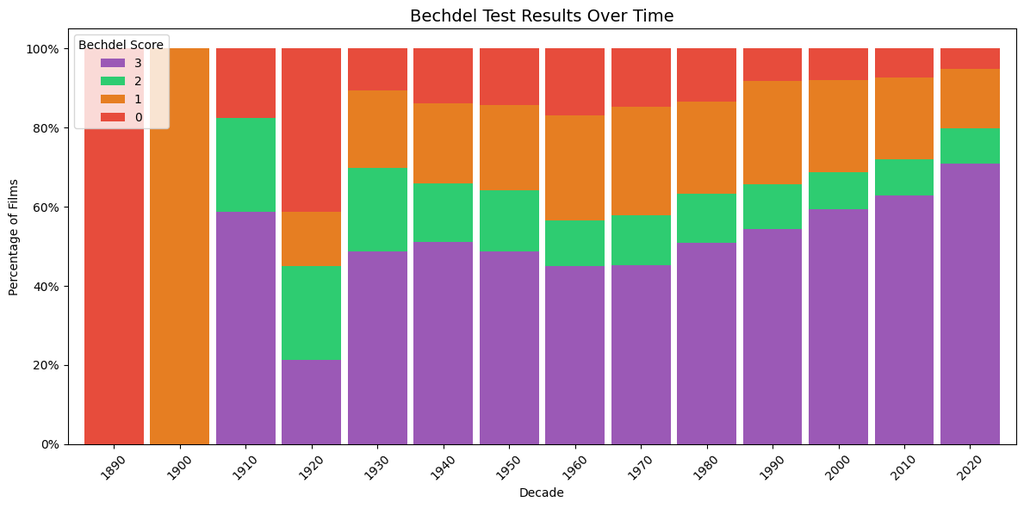

```
<class 'pandas.core.frame.DataFrame'>
RangeIndex: 9718 entries, 0 to 9717
Data columns (total 11 columns):
 #   Column             Non-Null Count  Dtype
---  ------             --------------  -----
 0   title              9718 non-null   object
 1   year               9718 non-null   int64
 2   imdbid             9718 non-null   float64
 3   id                 9718 non-null   int64
 4   bechdelRating      9718 non-null   int64
 5   imdbAverageRating  9718 non-null   float64
 6   numVotes           9718 non-null   float64
 7   runtimeMinutes     9718 non-null   object
 8   genre1             9718 non-null   object
 9   genre2             8446 non-null   object
```

[output cut: 39 more lines]

I have many categorical features that I may or may not decide to keep once I tidy, but the first step is merging the two on two common points: title and ID. The issue is I have IMDB IDs and TMDB IDs. To compare, I am going to pick the first movie from the TMDB dataset, Inception, and compare the data related to that movie from each set to see what matches.

```
BECHDEL
```

|  | title | year | imdbid | id |
| --- | --- | --- | --- | --- |
| 5959 | Inception | 2010 | 1375666.0 | 1169 |

```
TMDB
```

|  | title | release_date | tconst | id |
| --- | --- | --- | --- | --- |
| 0 | Inception | 2010-07-15 | tt1375666 | 27205 |
| 35024 | The Crack: Inception | 2019-10-04 | tt6793710 | 613092 |
| 112909 | WWA The Inception | 2001-10-26 | tt0311992 | 250845 |
| 193141 | Inception: Jump Right Into the Action | NaN | tt5295990 | 957443 |
| 204593 | Bikini Inception | 2015-05-19 | tt8269586 | 542438 |

It looks like "imdbid" corresponds to "tconst" but we'll have to eliminate the "tt" before the numbers to merge properly.

**Preparing datasets for merging:** I need to standardize the columns and movie titles by making them lower case, removing the "tt" before the ID on the TMDB dataset, removing spaces before and after labels, standardizing dates, and checking for missing values.

```
Missing imdbid in Bechdel: 0
Missing imdbid in TMDB: 0
```

**Merging datasets:** I am using an inner join since we want to find matches that exist in both lists since the Bechdel list doesn't have budget and revenue data and the TMDB list doesn't have Bechdel scores.

```
Merged rows: 6433
```

|  | title_bechdel | year | imdbid | id_bechdel | bechdelrating | imdbaveragerating | numvotes_bechdel | runtimeminutes | genre1 | genre2 | genre3 | title_clean | id_tmdb | title_tmdb | vote_average | vote_count | status | release_date | revenue | runtime | adult | backdrop_path | budget | homepage | tconst | original_language | original_title | overview | popularity | … |
| --- | --- | --- | --- | --- | --- | --- | --- | --- | --- | --- | --- | --- | --- | --- | --- | --- | --- | --- | --- | --- | --- | --- | --- | --- | --- | --- | --- | --- | --- | --- |
| 0 | Miss Jerry | 1894 | 9.0 | 9779 | 0 | 5.4 | 212.0 | 45 | Romance | NaN | NaN | miss jerry | 356151 | Miss Jerry | 5.0 | 3 | Released | NaT | 0 | 45 | False | /f7S45HvhMBGENSht2eajitJ3PYw.jpg | 0 | NaN | tt0000009 | en | Miss Jerry | The adventures of a female reporter in the 1890s. | 0.748 | … |
| 1 | Cleopatra | 1912 | 2101.0 | 2003 | 2 | 5.1 | 622.0 | 100 | Drama | History | NaN | cleopatra | 71266 | Cleopatra | 3.2 | 17 | Released | NaT | 0 | 88 | False | /9x0xYuFfGAeqEIx8jdZ2p8GsfbX.jpg | 0 | NaN | tt0002101 | en | Cleopatra | The fabled queen of Egypt's affair with Roman general Marc Antony is ultimately disastrous for both of them. | 2.314 | … |
| 2 | A Florida Enchantment | 1914 | 3973.0 | 4457 | 2 | 5.8 | 300.0 | 63 | Comedy | NaN | NaN | a florida enchantment | 110803 | A Florida Enchantment | 4.5 | 10 | Released | NaT | 0 | 63 | False | /cdsDg6qSJqDNwOZ6tTeuL5912Jz.jpg | 0 | NaN | tt0003973 | en | A Florida Enchantment | A young woman discovers a seed that can make women act like men and men act like women. She decides to take one, then slips one to her maid and another to her fiancé. The fun begins. | 1.421 | … |
| 3 | Gretchen the Greenhorn | 1916 | 6745.0 | 2008 | 3 | 6.4 | 537.0 | 58 | Crime | Drama | Romance | gretchen the greenhorn | 126925 | Gretchen the Greenhorn | 5.9 | 9 | Released | NaT | 0 | 58 | False | NaN | 0 | NaN | tt0006745 | en | Gretchen the Greenhorn | Gretchen Van Houck is just arriving in the USA, on a ship from Holland. She joins her father, who has already spent several years in America, where he owns an engraving business. In the tenement commu… | 1.343 | … |
| 4 | Snow White | 1916 | 7361.0 | 7004 | 3 | 6.3 | 444.0 | 63 | Fantasy | Romance | NaN | snow white | 174598 | Snow White | 5.7 | 11 | Released | NaT | 0 | 63 | False | NaN | 0 | NaN | tt0007361 | en | Snow White | Snow White, a beautiful girl, is despised by a wicked queen who tries to destroy her. With the aid of dwarfs in the woods, Snow White overcomes the queen. | 1.593 | … |

**Tidying data:**

First we'll check columns as there are some categorical features I will not be using.

```
<class 'pandas.core.frame.DataFrame'>
RangeIndex: 6433 entries, 0 to 6432
Data columns (total 42 columns):
 #   Column                Non-Null Count  Dtype
---  ------                --------------  -----
 0   title_bechdel         6433 non-null   object
 1   year                  6433 non-null   int64
 2   imdbid                6433 non-null   float64
 3   id_bechdel            6433 non-null   int64
 4   bechdelrating         6433 non-null   int64
 5   imdbaveragerating     6433 non-null   float64
 6   numvotes_bechdel      6433 non-null   float64
 7   runtimeminutes        6433 non-null   object
 8   genre1                6433 non-null   object
 9   genre2                5649 non-null   object
```

[output cut: 34 more lines]

For now, I'm going to keep title_bechdel, year, bechdelrating, runtime, budget, genre 1 and revenue. When analyzing why a movie produced a large box office return, cast is undoubtedly important, but the cast column here has a list of actors separated by comma. I may come back later and attempt to quantify star power, but for now, we'll drop it.

|  | title_bechdel | year | bechdelrating | budget | revenue | genre1 | runtime |
| --- | --- | --- | --- | --- | --- | --- | --- |
| 0 | Miss Jerry | 1894 | 0 | 0 | 0 | Romance | 45 |
| 1 | Cleopatra | 1912 | 2 | 0 | 0 | Drama | 88 |
| 2 | A Florida Enchantment | 1914 | 2 | 0 | 0 | Comedy | 63 |
| 3 | Gretchen the Greenhorn | 1916 | 3 | 0 | 0 | Crime | 58 |
| 4 | Snow White | 1916 | 3 | 0 | 0 | Fantasy | 63 |

Checking the merged table reveals some NaN values for our oldest films, which makes sense since the data is most likely more difficult to track for older films. Since we are focused on movies measured with the Bechdel Test specifically and modern movies generally, it makes sense to trim this dataset to only movies from 1985 to the present.

```
Movies before filtering: 6433
Movies after filtering: 5164
Earliest year in dataset: 1985
```

|  | title_bechdel | year | bechdelrating | budget | revenue | genre1 | runtime |
| --- | --- | --- | --- | --- | --- | --- | --- |
| 1269 | A Chorus Line | 1985 | 3 | 0 | 14202899 | Drama | 117 |
| 1270 | A Room with a View | 1985 | 3 | 3000000 | 20966644 | Drama | 117 |
| 1271 | A View to a Kill | 1985 | 1 | 30000000 | 152427960 | Action | 131 |
| 1272 | After Hours | 1985 | 2 | 4500000 | 10609321 | Comedy | 97 |
| 1273 | Agnes of God | 1985 | 3 | 0 | 0 | Drama | 98 |

There are still NaN values so it's time to drop rows with NaN values properly.

```
Rows after filtering financial data: 2854
```

I now have 2,854 movies. That is a good amount for my purposes but I need to check for duplicates.

```
np.int64(28)
```

```
Number of rows with duplicate title + year: 4
```

|  | title_bechdel | year | bechdelrating | budget | revenue | genre1 | runtime |
| --- | --- | --- | --- | --- | --- | --- | --- |
| 5901 | How to Train Your Dragon: The Hidden World | 2019 | 2 | 129000000 | 524580592 | Action | 104 |
| 5902 | How to Train Your Dragon: The Hidden World | 2019 | 3 | 129000000 | 524580592 | Action | 104 |
| 4880 | Into the Woods | 2014 | 3 | 50000000 | 212902372 | Adventure | 125 |
| 4881 | Into the Woods | 2014 | 3 | 50000000 | 212902372 | Adventure | 125 |

```
Final row count: 2852
```

|  | title_bechdel | year | bechdelrating | budget | revenue | genre1 | runtime |
| --- | --- | --- | --- | --- | --- | --- | --- |
| 0 | A Room with a View | 1985 | 3 | 3000000 | 20966644 | Drama | 117 |
| 1 | A View to a Kill | 1985 | 1 | 30000000 | 152427960 | Action | 131 |
| 2 | After Hours | 1985 | 2 | 4500000 | 10609321 | Comedy | 97 |
| 3 | Back to the Future | 1985 | 2 | 19000000 | 381109762 | Adventure | 116 |
| 4 | Brazil | 1985 | 3 | 15000000 | 9900000 | Drama | 143 |

I'm down to 2,852 films after deleting two rows. Now to confirm our NaNs are gone.

```
NaN counts per column:
title_bechdel    0
year             0
bechdelrating    0
budget           0
revenue          0
genre1           0
runtime          0
dtype: int64

Is the dataframe completely clean? True
```

|  | 0 |
| --- | --- |
| title_bechdel | object |
| year | int64 |
| bechdelrating | int64 |
| budget | int64 |
| revenue | int64 |
| genre1 | object |
| runtime | int64 |

**dtype:** object

I have two more features I want to add: ROI and Bechdel Pass/Fail.

ROI is return on investment. This is calculated as follows: $\text{ROI} = \frac{\text{Revenue - Budget}}{ \text{Budget}}$

For the Bechdel Test, it may be valuable to look among the different categories of movies -- i.e. films with 0 of 3 criteria, films with 1 of 3 criteria, etc. But I also want a binary value since all that matters for those who use the metric is whether or not a movie passes (meets all three criteria).

|  | title_bechdel | year | bechdelrating | budget | revenue | genre1 | runtime | ROI | bechdel_pass |
| --- | --- | --- | --- | --- | --- | --- | --- | --- | --- |
| 0 | A Room with a View | 1985 | 3 | 3000000 | 20966644 | Drama | 117 | 5.988881 | 1 |
| 1 | A View to a Kill | 1985 | 1 | 30000000 | 152427960 | Action | 131 | 4.080932 | 0 |
| 2 | After Hours | 1985 | 2 | 4500000 | 10609321 | Comedy | 97 | 1.357627 | 0 |
| 3 | Back to the Future | 1985 | 2 | 19000000 | 381109762 | Adventure | 116 | 19.058409 | 0 |
| 4 | Brazil | 1985 | 3 | 15000000 | 9900000 | Drama | 143 | -0.340000 | 1 |

# **Exploring the Data**

#### **Comparing significant statistics between passing and non-passing films**

Here I will do some light EDA looking for initial trends among the movies as a whole and among Bechdel passing movies v. non-passing movies.

Let's start by looking at what percent of movies pass the Bechdel Test.

```
Percentage of movies that pass the Bechdel Test: 56.24%
```

That's a fairly even split, which is great news!

Now let's look at ROI comparisons between passing and non-passing films.

```
Average ROI by Bechdel Status (0=Fail, 1=Pass):
bechdel_pass
0    1253.590833
1       4.181327
Name: ROI, dtype: float64
```

The ROI for non-passing films seems inflated. For context, a 2.5 ROI is considered a benchmark for films since a profit of 2.5 times the budget can usually cover marketing costs as well. Let's check for low budgets we missed that aren't zero.

```
Number of movies with budgets under $1,000: 3
```

I have three films with budgets below $1000. Let's see what they are.

|  | title_bechdel | year | budget | revenue | ROI |
| --- | --- | --- | --- | --- | --- |
| 15 | Kiss of the Spider Woman | 1985 | 11 | 17005229 | 1.545929e+06 |
| 235 | Kickboxer 2: The Road Back | 1991 | 89 | 1250712 | 1.405194e+04 |
| 271 | HouseSitter | 1992 | 26 | 94 | 2.615385e+00 |

Those budgets are incorrect, so I will remove these rows.

```
New row count: 2849
Minimum budget in dataset: $6000
```

Ok let's check out the average ROI again.

```
Average ROI by Bechdel Status (0=Fail, 1=Pass):
bechdel_pass
0    3.612764
1    4.181327
Name: ROI, dtype: float64
```

Much better! These are more in the normal range for movies. This is valuable insight as it shows the passing movies have a slightly higher ROI than non-passing, approximately 50 cents more per dollar spent.

This could be due to low budget films. Let's take a look at the average budget for passing v. non passing films.

```
Average budget by Bechdel Status (0=Fail, 1=Pass):
bechdel_pass
0   46,634,340.09
1   41,611,256.40
Name: budget, dtype: float64
```

As we can see, passing films average $5 million less in budget. That can definitely boost ROI.

Since movies can have massive outliers where an indie darling makes it big at the box office, let's create a boxplot to look for outliers.

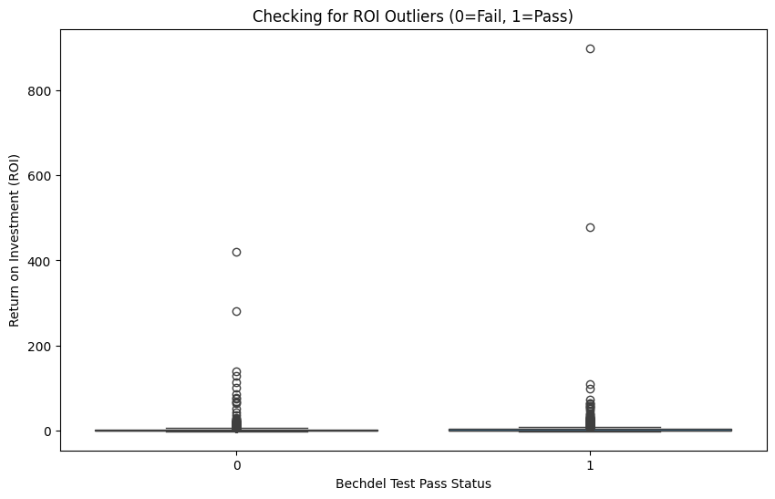

There are definitely some outliers! Let's take a closer look.

```
Number of extreme outliers (ROI > 50): 26
```

|  | title_bechdel | year | bechdelrating | budget | revenue | genre1 | runtime | ROI | bechdel_pass |
| --- | --- | --- | --- | --- | --- | --- | --- | --- | --- |
| 1331 | Paranormal Activity | 2007 | 3 | 215000 | 193355800 | Horror | 85 | 898.33 | 1 |
| 2488 | Secret Superstar | 2017 | 3 | 286284 | 137416709 | Drama | 150 | 479.00 | 1 |
| 950 | Open Water | 2003 | 1 | 130000 | 54667954 | Adventure | 79 | 419.52 | 0 |
| 262 | El Mariachi | 1992 | 0 | 7225 | 2040920 | Action | 81 | 281.48 | 0 |
| 2805 | Skinamarink | 2022 | 0 | 15000 | 2100000 | Horror | 100 | 139.00 | 0 |
| 1216 | Once | 2006 | 2 | 160000 | 20710513 | Drama | 85 | 128.44 | 0 |
| 1026 | Napoleon Dynamite | 2004 | 1 | 400000 | 46118097 | Comedy | 95 | 114.30 | 0 |
| 1105 | Keeping Mum | 2005 | 3 | 169000 | 18564702 | Comedy | 103 | 108.85 | 1 |
| 1588 | Catfish | 2010 | 0 | 30000 | 3045943 | Documentary | 87 | 100.53 | 0 |
| 574 | Kuch Kuch Hota Hai | 1998 | 3 | 153000 | 15306000 | Comedy | 185 | 99.04 | 1 |
| 1036 | Saw | 2004 | 2 | 1200000 | 103911669 | Horror | 103 | 85.59 | 0 |
| 1030 | Primer | 2004 | 1 | 7000 | 545436 | Drama | 77 | 76.92 | 0 |
| 2590 | Searching | 2018 | 1 | 1000000 | 75462037 | Drama | 102 | 74.46 | 0 |
| 863 | My Big Fat Greek Wedding | 2002 | 3 | 5000000 | 368744044 | Comedy | 95 | 72.75 | 1 |
| 850 | Infernal Affairs | 2002 | 1 | 125000 | 8708932 | Action | 101 | 68.67 | 0 |
| 1386 | Fireproof | 2008 | 2 | 500000 | 33456317 | Drama | 122 | 65.91 | 0 |
| 31 | Teen Wolf | 1985 | 2 | 1200000 | 80000000 | Comedy | 91 | 65.67 | 0 |
| 1627 | Insidious | 2010 | 3 | 1500000 | 99870886 | Horror | 103 | 65.58 | 1 |
| 42 | Crocodile Dundee | 1986 | 3 | 5000000 | 328203506 | Action | 104 | 64.64 | 1 |
| 2171 | Unfriended | 2014 | 3 | 1000000 | 62882090 | Horror | 82 | 61.88 | 1 |
| 2810 | Terrifier 2 | 2022 | 3 | 250000 | 15065239 | Horror | 138 | 59.26 | 1 |
| 1650 | Paranormal Activity 2 | 2010 | 3 | 3000000 | 177512032 | Horror | 91 | 58.17 | 1 |
| 2448 | Get Out | 2017 | 3 | 4500000 | 255407969 | Horror | 104 | 55.76 | 1 |
| 344 | Four Weddings and a Funeral | 1994 | 3 | 4400000 | 245700832 | Comedy | 117 | 54.84 | 1 |
| 586 | Pi | 1998 | 2 | 60000 | 3221152 | Drama | 84 | 52.69 | 0 |
| 243 | Slacker | 1991 | 3 | 23000 | 1228108 | Comedy | 97 | 52.40 | 1 |

Paranormal Activity has the highest ROI by far with 898. With our average ROIs down in the 3-4 range, it may make sense for us to either cut the top 1% of ROIs and/or use median over mean down the line.

First, let's check how passing v. non-passing films are represented among films with ROI over 50.

```
Percentage in the High ROI Table:
bechdel_pass
1   50.00
0   50.00
Name: proportion, dtype: float64
```

An exact 50/50 split!

### **Comparing mean and median ROIs**

Since we now know about the outliers, let's compare the median ROIs and budgets.

```
Median ROI by Bechdel Status (0=Fail, 1=Pass):
bechdel_pass
0   1.24
1   1.42
Name: ROI, dtype: float64
```

```
Median budget by Bechdel Status (0=Fail, 1=Pass):
bechdel_pass
0   30,000,000.00
1   22,000,000.00
Name: budget, dtype: float64
```

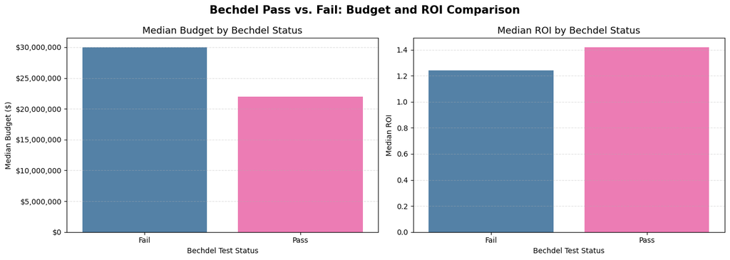

Our previous findings held up albeit they are now much more resistant to outliers since we compared medians. Bechdel Test passing films continue to appear to return slightly more profit with slightly lower budgets.

The search for outliers showed another trend in movie profitability: Horrors tend to have high returns since they can be produced for very low budgets, often in the woods or in someone's house. Let's look at ROI and budget per genre.

First, let's see how many movies we have per genre in case we have a genre with too few entries skewing the data.

```
Number of movies per genre:
genre1
Action         878
Comedy         687
Drama          449
Adventure      286
Crime          182
Biography      173
Horror         139
Animation       20
Fantasy         16
Mystery         12
Documentary      3
Sci-Fi           2
Family           1
Thriller         1
Name: count, dtype: int64
```

Unsurprisingly, there are a lot of action movies. I am concerned about the low number of entries for Animation, Fantasy, Mystery, Documentary, Sci-Fi, Family and Thriller. It may be worth it to combine these into an "Other" category.

```
Number of movies per genre:
genre1
Action       878
Comedy       687
Drama        449
Adventure    286
Crime        182
Biography    173
Horror       139
Other         55
Name: count, dtype: int64
```

Now I have 55 in the "Other" category. Let's look at ROI and budget per genre.

```
Mean vs Median ROI per Genre:
```

| genre1 | mean | median |
| --- | --- | --- |
| Horror | 16.55 | 3.41 |
| Adventure | 4.18 | 1.73 |
| Comedy | 3.63 | 1.40 |
| Action | 2.48 | 1.34 |
| Other | 4.60 | 1.12 |
| Drama | 4.63 | 1.01 |
| Crime | 2.17 | 0.92 |
| Biography | 1.84 | 0.75 |

As suspected, horror leads in ROI but that could also be the result of Paranormal Activity's heavy weight.

### **Female representation across eras**

I'd also like to examine the ROI of Bechdel passing movies pre-2014 and post-2014.

As mentioned in the introduction, post-2014 saw the #MeToo movement ignite an international modern women's rights movement, and anecdotally, that appeared to correlate with increased female-centric media. My hypothesis is that average ROI for passing films was lower after 2014 since more money was invested by larger production companies. Let's take a look by creating a new "era" feature and looking at mean and median ROI per era for passing and non-passing movies.

```
Comprehensive ROI Comparison Pre-2014 & Post-2014
```

|  | era | bechdel_pass | movie_count | mean_roi | median_roi |
| --- | --- | --- | --- | --- | --- |
| 0 | Post-2014 (Modern) | Fail | 294 | 2.69 | 1.09 |
| 1 | Post-2014 (Modern) | Pass | 510 | 4.38 | 1.68 |
| 2 | Pre-2014 | Fail | 951 | 3.90 | 1.26 |
| 3 | Pre-2014 | Pass | 1094 | 4.09 | 1.31 |

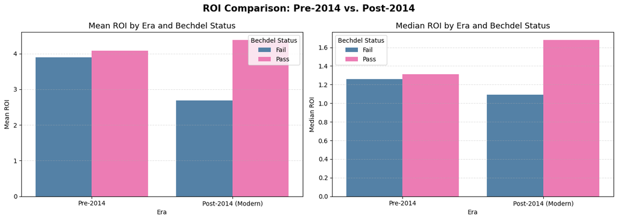

Interestingly, my hypothesis looks incorrect. Post-2014 passing films increased in mean and median ROI over pre-2014 passing films. Perhaps even more interestingly, non-passing films declined from pre- to post-2014 in mean and median ROI.

Let's look at how ROI has changed over time for passing v. non-passing films. First, I'm going to create a feature that lets me sort by decade.

|  | title_bechdel | year | decade |
| --- | --- | --- | --- |
| 0 | A Room with a View | 1985 | 1980 |
| 1 | A View to a Kill | 1985 | 1980 |
| 2 | After Hours | 1985 | 1980 |
| 3 | Back to the Future | 1985 | 1980 |
| 4 | Brazil | 1985 | 1980 |

Now I will plot passing median ROI over time v. non-passing. I am choosing median to limit the impact of outliers.

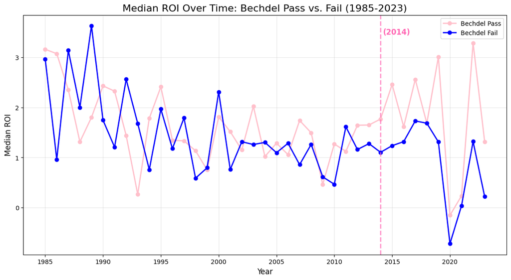

This is very interesting. We can see clearly how the ROI for movies that pass the Bechdel Test v. those that don't have inverted over time. (We can also clearly see the impact of COVID-19 on movie theatre business.)

Outliers have made us shy away from the mean, but in forecasting movies ROI, mean is a useful statistic. After all, if you can forecast returns on the next 10 movies you make, one of them could be a blockbuster that pays for the other nine. Let's look at the mean ROI over time.

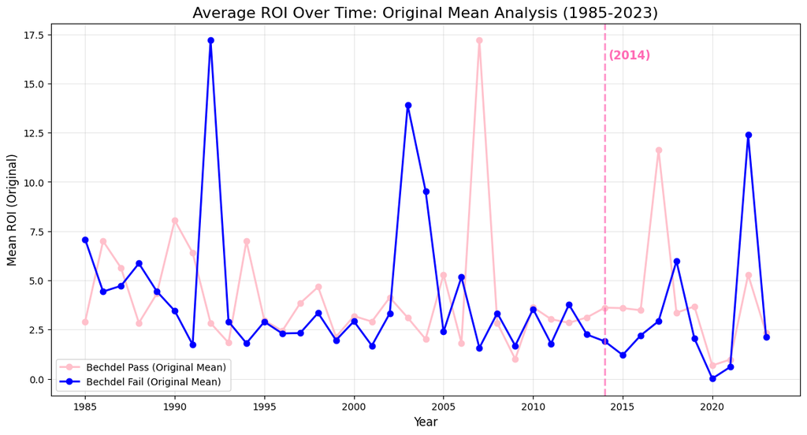

And there are the outliers. Bechdel-passing films post-2014 still appear to show higher ROI at first but now there is a flip post 2020.

### **Addressing the "paranormal activity" in the data (and other outliers)**

This brings us to our main decision before we get to modeling: determining what to do about the outliers. On the one hand, outliers are a natural part of moviemaking. Some make it big and some don't. On the other, we are trying to create a model that can most accurately tell us whether the Bechdel Test has any weight in determining ROI. To find out how things would differ without outliers, let's winsorize the ROI and cap the ceiling at the 99th percentile.

|  | title_bechdel | ROI | ROI_winsorized_99 |
| --- | --- | --- | --- |
| 1331 | Paranormal Activity | 898.33 | 39.51 |
| 2488 | Secret Superstar | 479.00 | 39.51 |
| 950 | Open Water | 419.52 | 39.51 |
| 262 | El Mariachi | 281.48 | 39.51 |
| 2805 | Skinamarink | 139.00 | 39.51 |
| 1216 | Once | 128.44 | 39.51 |
| 1026 | Napoleon Dynamite | 114.30 | 39.51 |
| 1105 | Keeping Mum | 108.85 | 39.51 |
| 1588 | Catfish | 100.53 | 39.51 |
| 574 | Kuch Kuch Hota Hai | 99.04 | 39.51 |

That is a dramatic difference! Again, a normal movie can hope for a $2.50 in profit for every dollar spent so $39.51 is still a major success.

Let's examine our ROI comparisons again with the winsorized ROI data. To do this, I will make a bar chart comparing mean and median winsorized ROI for passing and non-passing films.

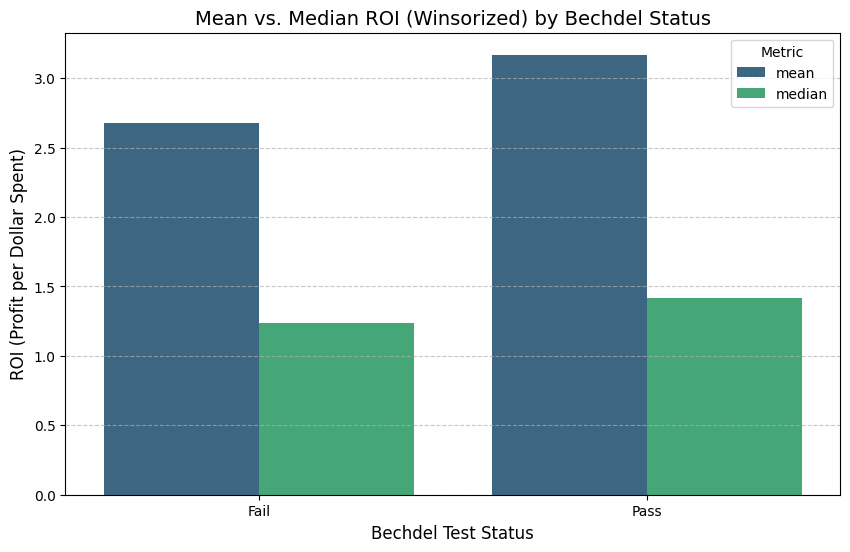

Ok these mean ROIs are now in a more realistic range post-winsorizing. Let's see how they compare to the previous non-winsorized ROIs.

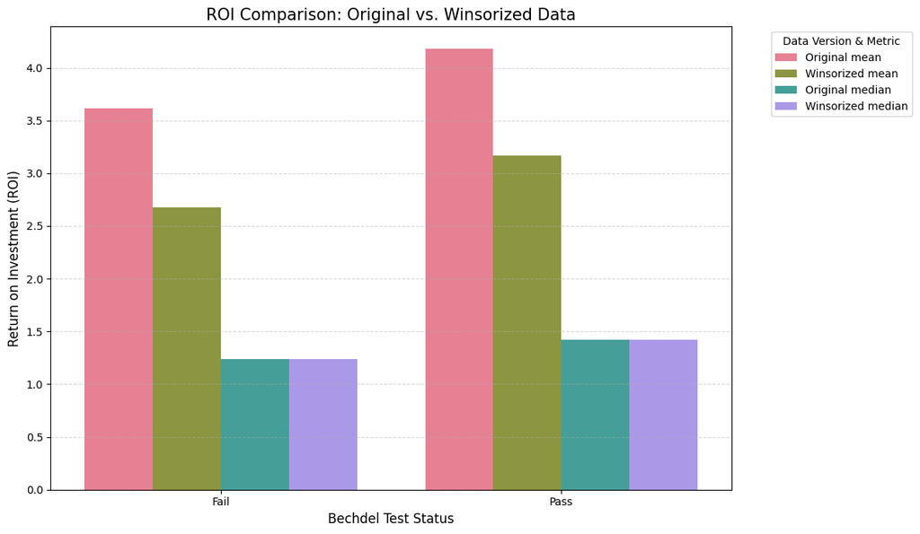

I think winsorizing the data was a good move. The medians did not change since we did not remove the movies from the dataset, which will allow us to have a greater sample size when modeling. The mean is now more reliable as a metric since we no longer have such massive outliers and has dropped into a more realistic range.

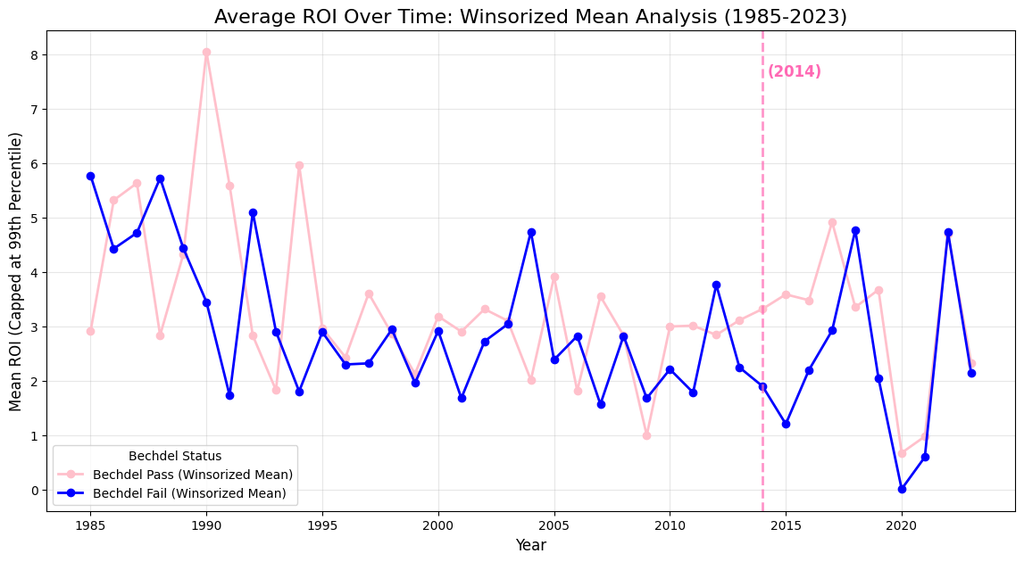

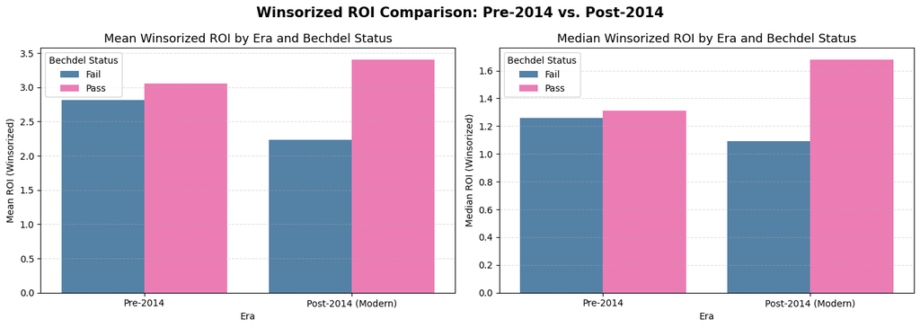

### **Breaking even: How many movies make their money back?**

One final area we haven't looked at is the split among movies that did not break even. Let's see how many movies failed to do that.

```
Number of movies that lost money (ROI < 0): 681
Percentage of dataset that lost money: 23.90%
```

Almost a quarter of our approximately 2,800 films failed to break even. Since marketing is an important part of the movie industry that our data doesn't account for, let's see what percentage of films failed to make back 2.5 times their budget, the baseline for earning back marketing expenditures.

```
Number of movies that didn't return profit (ROI < 2.5): 1901
Percentage of dataset that lost money: 66.73%
```

So almost exactly two-thirds of our films failed to get profit after covering marketing costs. It's hard to make a successful movie!

One last step before we decide on models: Let's see the breakdown of pass/fail movies in our new ROI buckets.

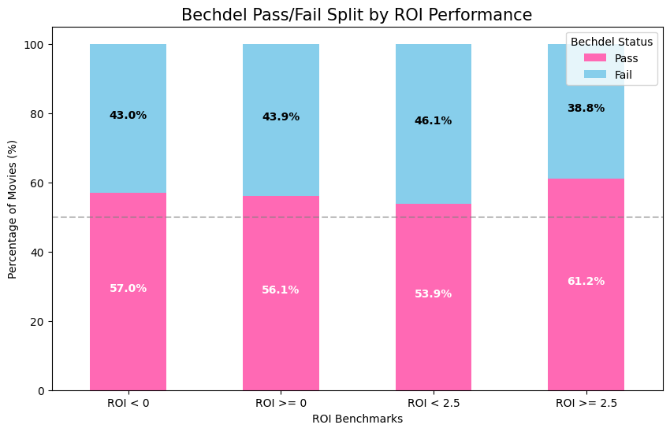

So this graph is useful for two reasons. One, it once again shows that Bechel passing movies can have a higher ROI, as shown by this jump in percentage in movies over 2.5 ROI.

Two, It gives us another way to frame the problem for modeling. We could create a binary ROI value at 2.5 with `<2.5` being "unprofitable" and `>2.5` being "profitable. This would allow me to create a decision tree that could answer whether or not passing the Bechdel Test can help predict if a movie will be profitable.

# **Models:**

#### **Model planning:**

For the modeling phase, I am creating six models with two goals:

Goal 1: Try to predict a film's ROI generally and determine if passing the Bechdel Test is significant to the outcome. A secondary goal is to see how this differs between pre- and post-2014. To do this I will create two pairs of linear regression models:

1. Pre-2014 and post-2014 multiple regression models to determine whether passing the Bechdel Test has any weight when predicting a movie's (winsorized) ROI from genre, runtime, Bechdel pass/fail, budget and an interaction term of Bechdel pass/fail multiplied by budget. The interaction term is to see if a movie budget’s effect on ROI changes depending on its Bechdel pass/fail. To include genre in the multiple regression model, I will convert them into dummy variables using one-hot encoding. I will drop one primary genre to serve as a baseline reference, allowing the model to control for the inherent profitability differences between genres. Hopefully this ensures that the impact of the Bechdel Test on ROI is isolated from genre-based trends.
2. Pre- and post-2014 multiple regression models using the same features but with lasso shrinkage applied to eliminate features deem inconsequential.

Goal 2: Try to predict if a movie will be profitable (make back 2.5 times its budget) and if passing the Bechdel Test is a significant feature. To do this I will create two models:

1. A decision tree. While the multiple regression model predicts exact ROI values, the decision tree will only try to see what factors are important in determining if a movie is profitable or unprofitable. I have set the threshold at 2.5, aligning with the film industry’s '2.5x Rule,' which suggests a movie must gross 2.5 times its production budget to cover marketing costs and theater splits. This may help us capture non-linear patterns that regression could miss. The splits will tell us what features are important.
2. A random forest. This will have the same aproach as the decision tree while putting many trees together and working to create distinct trees that eliminate strong predictors from dominating the model.

I initially chose 2014 as the cutoff since that 2014 and beyond was not covered by the FiveThirtyEight analysis that sparked this project. Further research into sentiment shifts and the ROI over time graphs above confirmed that this will work as a year to represent a potential shift in audience and studio views about female representation in films.

The downside is there will be much less data for the post-2014 analysis.

### **Data prep for regression modeling:**

We have two final tweaks to do to our feature set: Creating a bechel_pass/budget interaction term and one hot encoding the genre feature, which is currently not numeric.

Ok, we're ready to make some models! First steps are making the train/test split and scaling.

### **Regression modeling: Pre-2014 and Post-2014**

#### **Normalization/standardization and train/test split**

```
Pre-2014 train/test: (1636, 11) (409, 11)
Post-2014 train/test: (643, 11) (161, 11)
```

Here we see the size of the post-2014 training set (643) and test set (161). The lack of data may hurt model performance.

#### **Pre-2014 baseline regression model:**

```
Pre-2014 CV R² scores: [0.02008386 0.0482893  0.01351569 0.04383575 0.05267667]
Mean CV R²: 0.0357 (+/- 0.0158)

Test R²: 0.0360
Test RMSE: 5.7010

Coefficients:
```

|  | Feature | Coefficient |
| --- | --- | --- |
| 9 | genre1_Horror | 4.30 |
| 4 | genre1_Adventure | 1.35 |
| 6 | genre1_Comedy | 0.48 |
| 8 | genre1_Drama | 0.37 |
| 1 | runtime | 0.35 |
| 3 | bechdel_x_budget | 0.32 |
| 10 | genre1_Other | -0.07 |
| 2 | bechdel_pass | -0.60 |
| 7 | genre1_Crime | -0.71 |
| 0 | budget | -1.07 |
| 5 | genre1_Biography | -1.08 |

The coefficients point toward outliers still posing problems. Horow is the dominant coefficient. Our bechdel/budget interaction term is not very important and passing the bechdel test has a slightly negative impact on ROI.

The RMSE of 5.7 is also far too high for this model to be useful, indicating an error of $5.70 profit per dollar spent when $2.50 is the baseline for profitability.

R-squared also shows this model only explains 3.6% of ROI return. More signs that the model is not great.

#### **Post-2014 baseline regression model:**

```
Post-2014 CV R² scores: [ 0.10000071  0.28389318  0.1154935   0.21422096 -0.06501076]
Mean CV R²: 0.1297 (+/- 0.1183)

Test R²: -0.5525
Test RMSE: 4.0972

Coefficients:
```

|  | Feature | Coefficient |
| --- | --- | --- |
| 9 | genre1_Horror | 11.33 |
| 10 | genre1_Other | 2.62 |
| 8 | genre1_Drama | 0.82 |
| 2 | bechdel_pass | 0.46 |
| 1 | runtime | 0.34 |
| 3 | bechdel_x_budget | 0.28 |
| 4 | genre1_Adventure | 0.25 |
| 6 | genre1_Comedy | 0.17 |
| 7 | genre1_Crime | -0.42 |
| 0 | budget | -0.54 |
| 5 | genre1_Biography | -1.23 |

Post-2014, passing the Bechdel Test shows a small flip from a negative coefficient to a positive coefficient. But a negative R-squared means the model is performing worse than a horizontal line. The error rate is lower but still higher than desired. Horror continues to show its connection to high ROI.

Let's check on what's behind the high horror coefficient.

```
count   161.00
mean      2.17
std       3.30
min      -1.00
25%      -0.03
50%       1.32
75%       3.22
max      18.30
Name: ROI_winsorized_99, dtype: float64
genre1_Horror
False    763
True      41
Name: count, dtype: int64
```

Let's test Lasso shrinkage to see if eliminating some features will help performance. Alternatively, if Lasso decides to eliminate our Bechdel features, that's another important finding.

#### **Regression models with shrinkage (lasso):**

```
=== Pre-2014 Lasso ===
Best alpha: 0.0112
Test R²: 0.0387
Test RMSE: 5.6930

Coefficients (zeroed out = eliminated by Lasso):
```

|  | Feature | Coefficient |
| --- | --- | --- |
| 9 | genre1_Horror | 3.96 |
| 4 | genre1_Adventure | 1.14 |
| 6 | genre1_Comedy | 0.35 |
| 1 | runtime | 0.31 |
| 8 | genre1_Drama | 0.24 |
| 2 | bechdel_x_budget | 0.24 |
| 10 | genre1_Other | -0.00 |
| 3 | bechdel_pass | -0.42 |
| 7 | genre1_Crime | -0.60 |
| 5 | genre1_Biography | -0.90 |
| 0 | budget | -1.00 |

```
=== Post-2014 Lasso ===
Best alpha: 0.0417
Test R²: -0.4347
Test RMSE: 3.9386

Coefficients (zeroed out = eliminated by Lasso):
```

|  | Feature | Coefficient |
| --- | --- | --- |
| 9 | genre1_Horror | 10.36 |
| 3 | bechdel_pass | 0.59 |
| 8 | genre1_Drama | 0.45 |
| 1 | runtime | 0.21 |
| 2 | bechdel_x_budget | 0.07 |
| 7 | genre1_Crime | -0.00 |
| 4 | genre1_Adventure | 0.00 |
| 10 | genre1_Other | 0.00 |
| 6 | genre1_Comedy | -0.00 |
| 0 | budget | -0.36 |
| 5 | genre1_Biography | -0.91 |

#### **Regression models comparison table:**

Let's compare our regression models.

|  | Model | CV R² | Test R² | Test RMSE | bechdel_pass coef | bechdel_pass p-value | bechdel survived Lasso |
| --- | --- | --- | --- | --- | --- | --- | --- |
| 0 | Pre-2014 OLS | 0.04 | 0.04 | 5.70 | -0.60 | 0.13 | None |
| 1 | Pre-2014 Lasso | NaN | 0.04 | 5.69 | -0.43 | NaN | Yes |
| 2 | Post-2014 OLS | 0.13 | -0.55 | 4.10 | 0.46 | 0.43 | None |
| 3 | Post-2014 Lasso | NaN | -0.44 | 3.94 | 0.60 | NaN | Yes |

So we have four regression models that are all bad at predicting ROI. Post-2014 Lasso had the lowest error. While we do see a shift with Bechdel passing movies going from a negative correlation to a positive post-2014, it's a negligible amount of difference. Notably, the feature was not eliminated by the lasso model, but it's still clearly insignificant. The NaN p-value is also a sign that something is not right with the model.

Since median absolute error penalizes outliers less heavily, let's check MAEs for each.

```
Pre-2014 OLS MedAE: 2.2879059157252466
Pre-2014 Lasso MedAE: 2.330184847274047
Post-2014 OLS MedAE: 2.170351957359128
Post-2014 Lasso MedAE: 2.302747591380732
```

|  | Model | CV R² | Test R² | Test RMSE | bechdel_pass coef | bechdel_pass p-value | bechdel survived Lasso | MedAE |
| --- | --- | --- | --- | --- | --- | --- | --- | --- |
| 0 | Pre-2014 OLS | 0.04 | 0.04 | 5.70 | -0.60 | 0.13 | None | 2.29 |
| 1 | Pre-2014 Lasso | NaN | 0.04 | 5.69 | -0.43 | NaN | Yes | 2.33 |
| 2 | Post-2014 OLS | 0.13 | -0.55 | 4.10 | 0.46 | 0.43 | None | 2.17 |
| 3 | Post-2014 Lasso | NaN | -0.44 | 3.94 | 0.60 | NaN | Yes | 2.30 |

Lower but again, too high of an error for these models to be useful.

Let's compare the Bechdel_pass and bechdel_x_budget coefficients across the models.

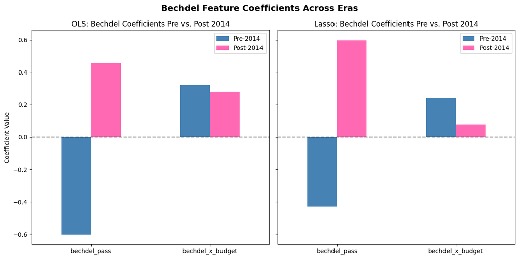

We see the slight flip in significance from movies that pass the Bechdel Test post-2014. We also see the Bechdel/budget interaction term losing significance. Post-2014, there are more big budget films passing the Bechdel Test. This could be interpreted as a sign that a scarcity premium eroded post-2014 and passing the Bechdel with a large budget became less of an indicator.

Let's get a visual of how well the model plotted predicted ROI.

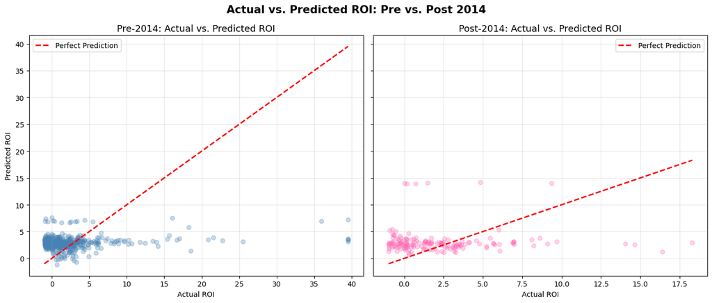

As we can see, the models struggle to capture high ROI outliers.

#### **Decision Tree model:**

```
              precision    recall  f1-score   support

           0       0.75      0.52      0.61       380
           1       0.40      0.65      0.50       190

    accuracy                           0.56       570
   macro avg       0.57      0.58      0.55       570
weighted avg       0.63      0.56      0.57       570
```

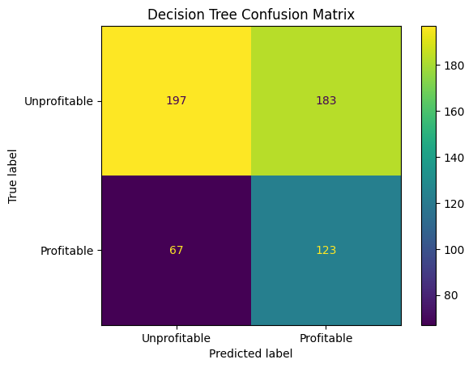

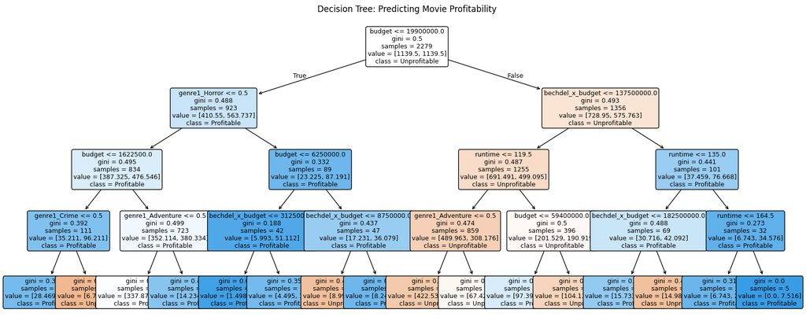

|  | Feature | Importance |
| --- | --- | --- |
| 0 | budget | 0.42 |
| 3 | bechdel_x_budget | 0.24 |
| 9 | genre1_Horror | 0.12 |
| 1 | runtime | 0.10 |
| 4 | genre1_Adventure | 0.08 |
| 7 | genre1_Crime | 0.04 |
| 2 | bechdel_pass | 0.00 |
| 6 | genre1_Comedy | 0.00 |
| 5 | genre1_Biography | 0.00 |
| 8 | genre1_Drama | 0.00 |
| 10 | genre1_Other | 0.00 |

The Bechdel/budget feature has the second highest importance, but the model is only 56% accurate at predicting profitability. The model struggled mostly with false positives, predicting movies would be profitable when they weren't. This could again be indiciative of outliers skewing results.

Checking the ROC-AUC.

```
Decision Tree AUC: 0.5981
```

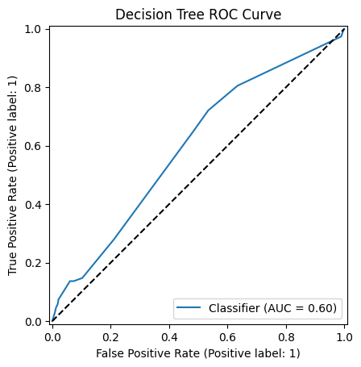

The ROC curve stays above the diagonal but not by much. The decision tree’s AUC of about 0.60 means it ranks profitable movies above unprofitable ones better than chance overall, but only by a limited amount.

Overall, this reinforces that movie profitability is difficult to predict both generally and from the features we're looking at.

#### **Random Forest model:**

```
=== Random Forest ===
              precision    recall  f1-score   support

Unprofitable       0.70      0.72      0.71       380
  Profitable       0.41      0.39      0.40       190

    accuracy                           0.61       570
   macro avg       0.56      0.56      0.56       570
weighted avg       0.61      0.61      0.61       570

Random Forest AUC: 0.6009
```

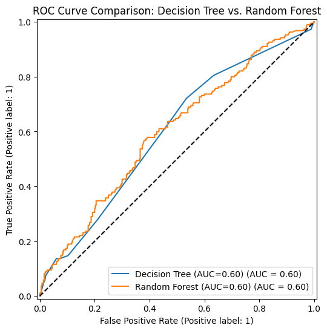

|  | Feature | Random Forest | Decision Tree |
| --- | --- | --- | --- |
| 0 | budget | 0.39 | 0.42 |
| 3 | bechdel_x_budget | 0.18 | 0.24 |
| 1 | runtime | 0.15 | 0.10 |
| 9 | genre1_Horror | 0.14 | 0.12 |
| 2 | bechdel_pass | 0.04 | 0.00 |
| 7 | genre1_Crime | 0.04 | 0.04 |
| 4 | genre1_Adventure | 0.03 | 0.08 |
| 5 | genre1_Biography | 0.01 | 0.00 |
| 8 | genre1_Drama | 0.01 | 0.00 |
| 6 | genre1_Comedy | 0.01 | 0.00 |
| 10 | genre1_Other | 0.00 | 0.00 |

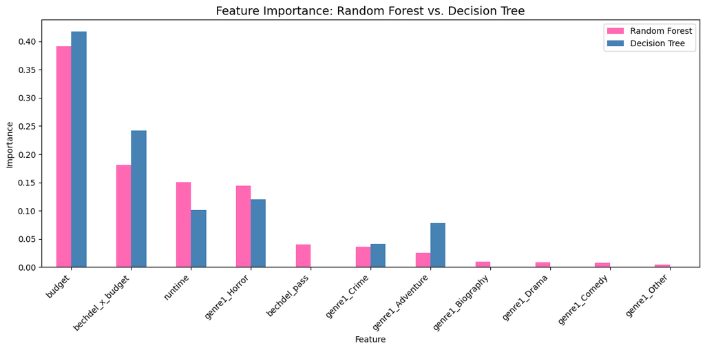

# **Conclusion:**

In the end, the models fell short of conclusively indiciating that more female representation in movies leads to higher return on investment. Movie budgets are hard to predict in general, though these models also very clearly had some issues such as handling outliers and a somewhat limited feature set.

The regression models showed some slight evidence of a 2014 sentiment shift but could not escape the outliers that define Hollywood blockbuster success. Paranormal Activity is an example of a low-budget, Bechdel-passing, horror film that can make a producer look savvy for choosing to bankroll it. This model will not be able to predict the next such film. The classification models did not fare better.

There are also some limitations to be addressed. First, marketing and talent have huge impacts on ROI. This model did not account for ad spending or the inclusion of Pedro Pascal on the cast list. There is perhaps a way to model A-listers by assigning each name present in the dataset a 1 or 0 depending on their prior award status. I considered including original language as a feature, however, 94% of the films were originally in English and the advantages of English-speaking, Western film industries are well established. Winsorization attempted to solve the outlier problem but perhaps I needed to further cull the top range of ROIs.

Finally, attempting to model ROI from the Bechdel Test may be a flaw in itself. I omitted including BechdelTest.com vote tallies or moviegoer ratings for fear of using post-release data for pre-release predictions. But audience members also cannot know a movie passes the Bechdel Test until after it comes out (barring highly discerning viewings of trailers). The Bechdel Test has also come under scrutiny as a measure of female representation in movies. For example, the 2013 film Gravity featured Sandra Bullock alone in space for much of the runtime, but this movie fails the test. Perhaps there is another way to measure representation by feeding scripts into an LLM to determine percentage of screentime/dialogue, and further exploration can be embarked upon from there.

[output not shown]

[output not shown]

[output cut: 136 more lines]

[output not shown]